# Pauta Tarea 2

Facultad de Economía y Negocios, Universidad de Chile, Chile

2018-10-15 (updated: 2019-05-29)

**Instrucciones**

1. Esta tarea debe ser entregada en **grupos de 2 o 3 personas**.
2. Se debe enviar una carpeta comprimida que contenga: un archivo .Rproj (proyecto en R) y un breve informe en R Markdown con sus resultados, incluyendo tablas, gráficos, etc., según corresponda. El formato del informe puede ser word o pdf.
3. El asunto del email con su tarea debe ser “Tarea 1-R 1-Apellido 1-Apellido 2-Apellido 3”
4. La fecha de entrega es el Domingo 5 de Mayo del 2019 hasta las 23:59 hrs al correo del curso: r2019curso@gmail.com.

> “The Visual Display of Quantitative Information”

> *Edward R. Tufte*, Above all else show the data

# Pregunta 1

El archivo googleplaystore.csv contiene información sobre las aplicaciones existentes en Google Play Store. Cargue la base datos utilizando el paquete `readr` y responda las siguientes preguntas.

Diccionario de datos

| N° | Variable | Clase | Descripción |
| --- | --- | --- | --- |
| 1 | App | chr | Nombre de la Aplicación |
| 2 | Category | chr | Categoría a la que pertenece la aplicación |
| 3 | Rating | dbl | Rating asignado por los usuarios |
| 4 | Reviews | int | Número de reseñas entregado por los usuarios |
| 5 | Size | chr | Tamaño de la aplicación |
| 6 | Installs | chr | Número de veces en que se instaló/descargó |
| 7 | Type | chr | Pagado o gratis |
| 8 | Price | chr | Precio de la aplicación |
| 9 | Content Rating | chr | Grupo etario objetivo: Children / Mature 21+ / Adult |
| 10 | Genres | chr | Una aplicación puede pertenecer a multiples géneros (aparte de su categoría principal) |
| 11 | Last Updated | chr | Última actualización de la aplicación. |
| 12 | Current Ver | chr | Versión actual de la aplicación disponible en Play Store |
| 13 | Android Ver | chr | Versión Android mínimo requerido |

## Pregunta 1.1

Use un gráfico de densidad para visualizar el rating. Debe tener en consideración la existencia de *missing values* y *NaN*. Comente.

```r
if(!require("pacman")) install.packages("pacman")
p_load("tidyquant", "janitor")
```

```r
google_plays_store_tbl <- read_csv("dataset/googleplaystore.csv") %>%
  clean_names()
```

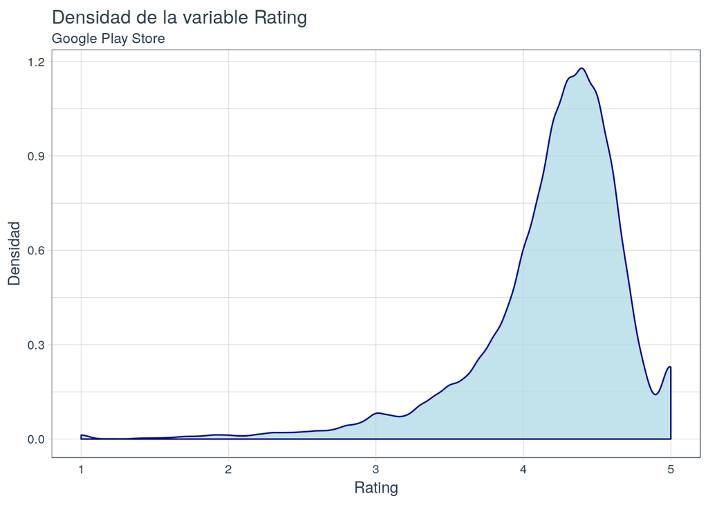

```r
density_plot_tbl <- google_plays_store_tbl %>%
  na.omit() %>%
  select(rating) %>%
  filter(!is.nan(rating)) %>%
  ggplot(mapping = aes(x=rating)) +
  labs(title = "Densidad de la variable Rating",
    subtitle = "Google Play Store",
    x = "Rating",
    y = "Densidad") +
  geom_density(color="darkblue",
    fill="lightblue", alpha = 0.75) +
  theme_tq()
```

## Pregunta 1.2

Muestre en un gráfico de barra la cantidad de aplicaciones por categoría. Comente.

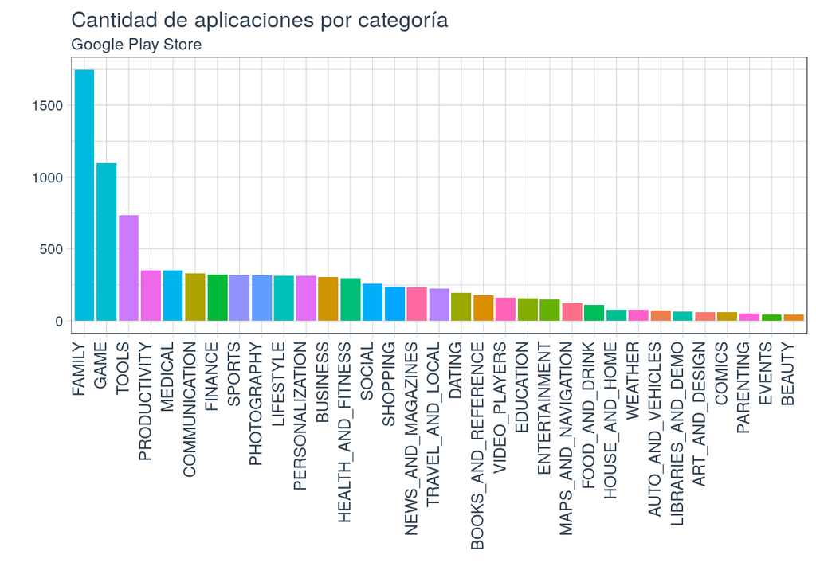

```r
app_by_category_tbl <- google_plays_store_tbl %>%
  na.omit() %>%
  select(category) %>%
  group_by(category) %>%
  mutate(count=n()) %>%
  ungroup() %>%
  distinct() %>%
  ggplot(aes(x=reorder(category, -count), y=count, fill=as_factor(category))) +
  labs(title = "Cantidad de aplicaciones por categoría",
    subtitle = "Google Play Store",
    x = "",
    y = "") +
  geom_bar(stat="identity") +
  theme_tq() + theme(legend.position = "none",
                     axis.text.x=element_text(size = 10, angle = 90,
                                              vjust = 0, hjust = 1))
```

## Pregunta 1.3

Utilizando un boxplot, muestre los cuartiles del rating para cada grupo etario. Comente.

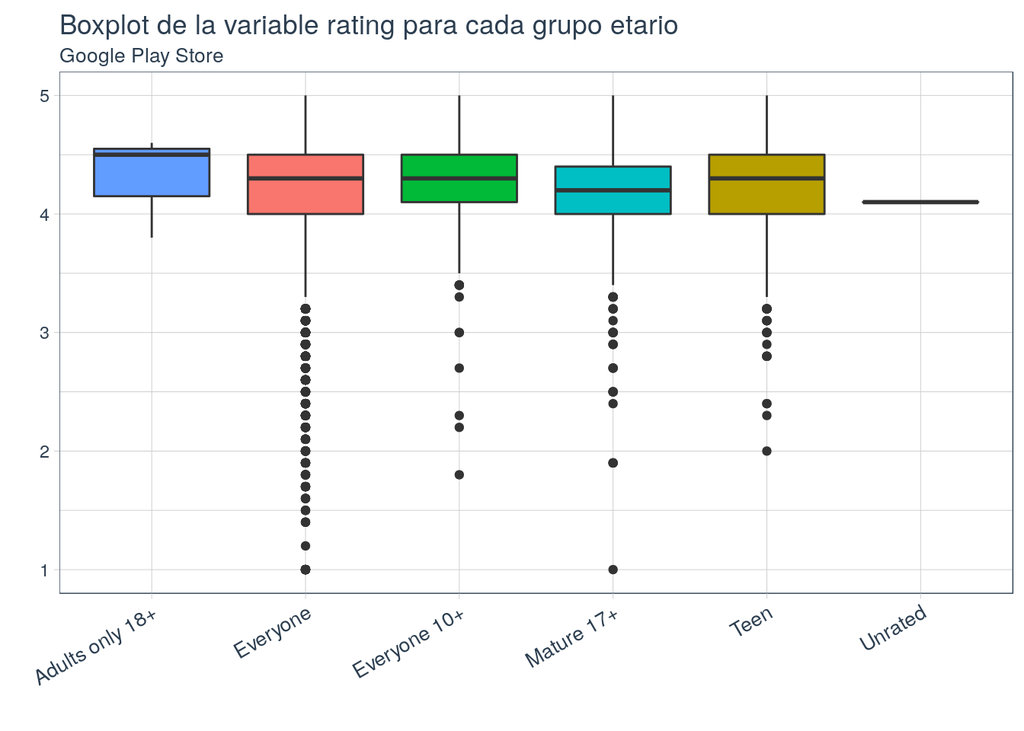

```r
    rating_plot_tbl <- google_plays_store_tbl %>%
      na.omit() %>%
      select(content_rating, rating) %>%
      filter(!is.nan(rating)) %>%
      group_by(content_rating) %>%
      ggplot(aes(factor(content_rating), rating, fill=as_factor(content_rating))) +
      geom_boxplot() +
      labs(title = "Boxplot de la variable rating para cada grupo etario",
        subtitle = "Google Play Store",
        x = "",
        y = "") +
      theme_tq() +
      theme(legend.position = "none",
            axis.text.x=element_text(size = 10, angle = 30,
                                     vjust = 1, hjust = 1))
```

## Pregunta 1.4

Use un gráfico de violín que permita la comparación de las distribuciones del rating según si es gratis o pagado. Comente.

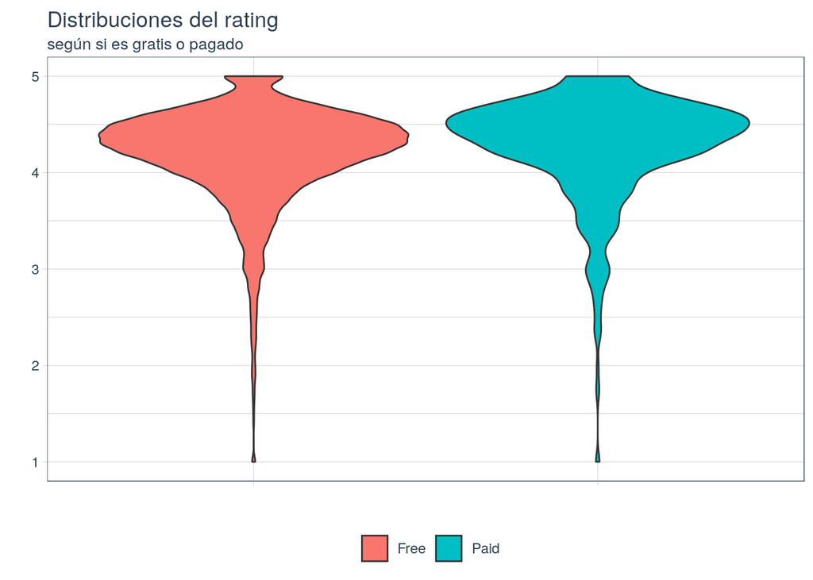

```r
violin_plot_tbl <- google_plays_store_tbl %>%
  na.omit() %>%
  select(type, rating) %>%
  filter(!is.nan(rating)) %>%
  group_by(type) %>%
  ggplot(aes(type, rating, fill=type)) +
  geom_violin() +
  labs(title = "Distribuciones del rating",
       subtitle = "según si es gratis o pagado",
       x = "",
       y = "",
       fill = "") +
  theme_tq() + theme(axis.text.x=element_blank())
```

## Pregunta 1.5

Calcule el porcentaje de reviews por año[^1]. Presente sus resultados usando un gráfico de torta que considere sólo los años 2017 y 2018. Comente.

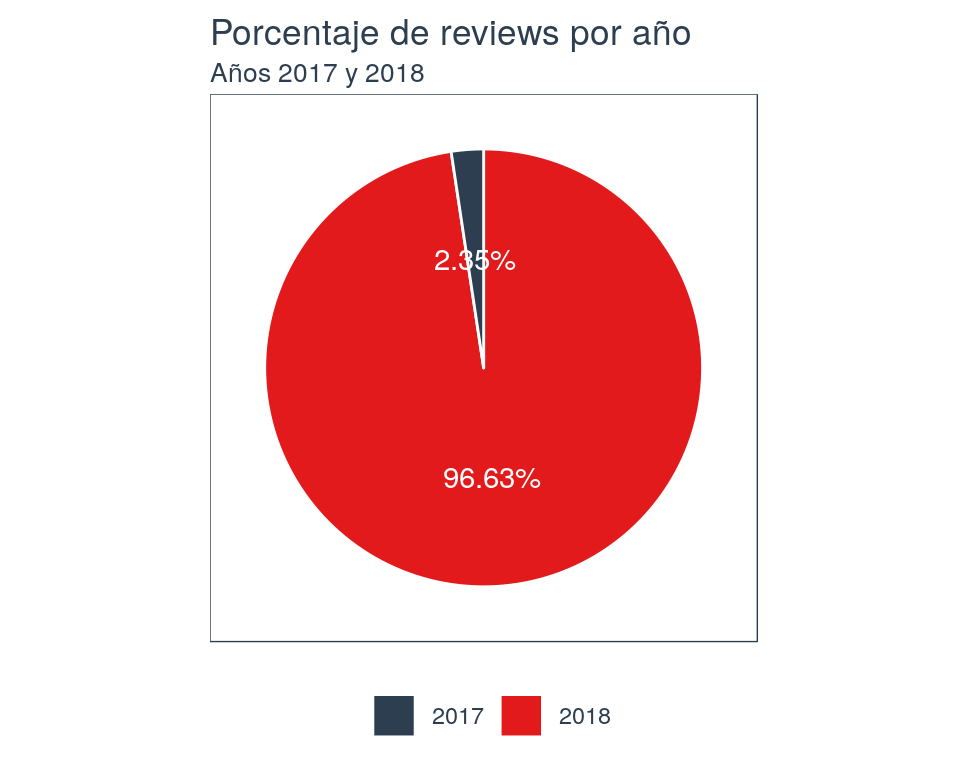

```r
pie_plot_tbl <- google_plays_store_tbl %>%
  na.omit() %>%
  select(reviews, last_updated) %>%
  mutate(year = str_extract(last_updated, ".\\d{4}"),
         year = as.numeric(year)) %>%
  select(reviews, year) %>%
  mutate(total = sum(as.numeric(reviews))) %>%
  group_by(year) %>%
  mutate(n = sum(as.numeric(reviews)), perc = n/total)  %>%
  filter(row_number(year)==1) %>%
  select(year, perc) %>%
  ungroup() %>%
  filter(year >= 2017) %>%
  mutate(year = as.character(year)) %>%
  ggplot(aes(x = "", y = perc, fill = year)) +
  geom_bar(stat = "identity", color = "white", width = 1) +
  coord_polar("y", start = 0) +
  geom_text(aes(label =  paste0(round(perc*100, 2), "%")),
            color = "white", position = position_stack(vjust = 0.5)) +
  labs(title = "Porcentaje de reviews por año",
       subtitle = "Años 2017 y 2018",
       x = NULL,
       y = NULL,
       fill = NULL) +
  theme_tq() +
  scale_fill_tq() +
  theme(axis.text = element_blank(),
        axis.ticks = element_blank(),
        panel.grid  = element_blank())
```

# Pregunta 2

## Pregunta 2.1

Utilizando `tidyquant` descargue los precios diarios para las siguientes empresas tecnológicas: Oracle (ORCL), Nvidia (NVDA), AMD (AMD) y Amazon (AMZN) desde Enero del 2000 hasta Diciembre del 2018.

```r
library("tidyquant")
```

```r
symbol <- c("ORCL", "NVDA", "AMD", "AMZN")
```

```r
stock_daily_tbl <- tq_get(symbol,
                    from = "2000-01-01",
                    to = "2019-01-01",
                    perdiodicity = "daily")
```

## Pregunta 2.2

Calcule los retornos mensuales y retornos acumulados mensuales para cada activo, luego grafique. Comente.

```r
stocks_daily_to_monthly_tbl <- stock_daily_tbl %>%
  select(date, symbol, close) %>%
  group_by(symbol) %>%
  tq_transmute(mutate_fun = to.monthly,
               indexAt = "lastof") %>%
  mutate(date = as.Date(as.yearmon(date))) %>%
  select(date, symbol, close) %>%
  spread(symbol, close)
```

```r
stock_returns_monthly_tbl <- stocks_daily_to_monthly_tbl %>%
  gather(symbols, close, -date) %>%
  group_by(symbols) %>%
  tq_transmute(mutate_fun = periodReturn,
               period = "monthly",
               type = "log",
               col_rename = "returns_monthly"
              ) %>%
  slice(-1) %>%
  mutate(date = as.Date(as.yearmon(date))) %>%
  spread(symbols, returns_monthly)
```

[figure not shown]

```r
stock_returns_monthly_tbl  %>%
  gather(symbol, returns, -date) %>%
  ggplot(mapping = aes(x = returns, fill = symbol)) +
  geom_density(alpha = 0.5) +
  labs(title = "Retornos Activos",
       subtitle = "Oracle (ORCL), Nvidia (NVDA), AMD (AMD) y Amazon (AMZN)",
       x = "Retornos diarios", y = "Densidad") +
  theme_tq() +
  scale_fill_tq() +
  facet_wrap(~ symbol, ncol = 2) +
  guides(fill=guide_legend(title="Activos:"))
```

```r
stock_returns_acum_monthly_tbl <- stock_returns_monthly_tbl %>%
  gather(symbol, returns, -date) %>%
  group_by(symbol) %>%
  mutate(returns_acum = cumsum(returns)) %>%
  select(-returns) %>%
  spread(symbol, returns_acum)
```

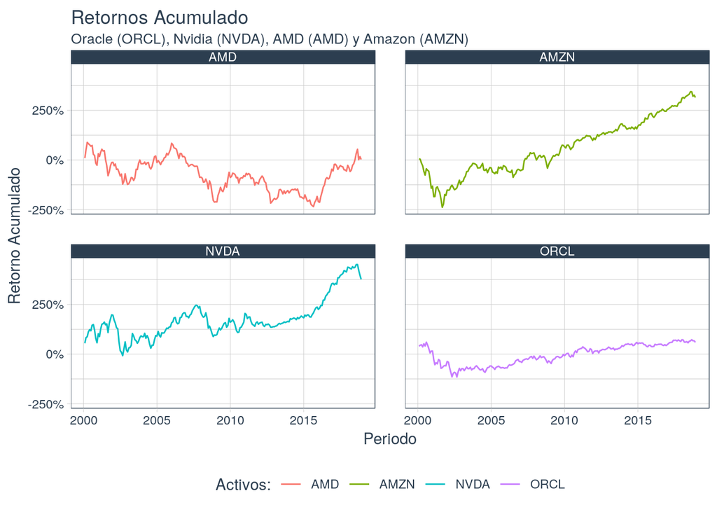

```r
stock_returns_acum_monthly_tbl %>%
  gather(symbol, returns_acum, -date) %>%
  ggplot(mapping = aes(x = date, y = returns_acum, color = symbol)) +
  geom_line() +
  labs(title = "Retornos Acumulado",
       subtitle = "Oracle (ORCL), Nvidia (NVDA), AMD (AMD) y Amazon (AMZN)",
       x = "Periodo", y = "Retorno Acumulado") +
  theme_tq() +
  scale_fill_tq() +
  facet_wrap(~ symbol, ncol = 2) +
  guides(color = guide_legend(title="Activos:")) +
  scale_y_continuous(labels = scales::percent)
```

## Pregunta 2.3

Use un Q-Q plot para comparar la distribución de los retornos de cada activo. Comente.

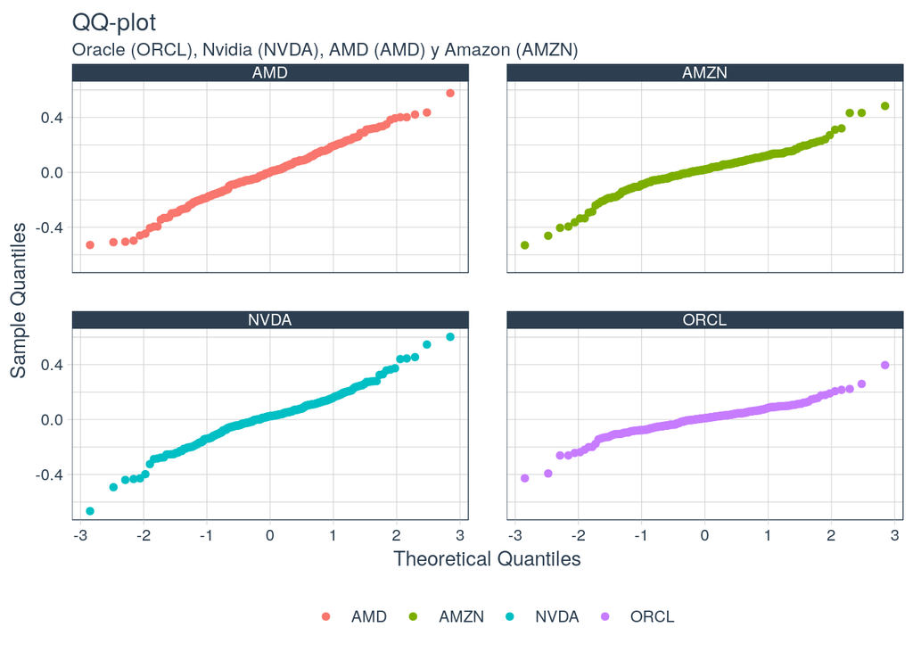

```r
stock_returns_monthly_tbl %>%
  gather(symbol, return, -date) %>%
  select(date, symbol, return) %>%
  ggplot(mapping = aes(sample = return, color = symbol)) +
  stat_qq() +
  labs(title = "QQ-plot",
       subtitle = "Oracle (ORCL), Nvidia (NVDA), AMD (AMD) y Amazon (AMZN)",
       x = "Theoretical Quantiles", y = "Sample Quantiles", color = "") +
  theme_tq() +
  scale_fill_tq() +
  facet_wrap(~ symbol, ncol = 2)
```

## Pregunta 2.4

Realice un análisis técnico mediante el uso de las bandas de Bollinger. Comente.

```r
end <- as_date("2018-12-01")
```

```r
bbands_function <- function(dat, sym){
  ggplot(dat, aes(x = date, y = close, open = open,
                  high = high, low = low, close = close)) +
    geom_candlestick() +
    geom_bbands(ma_fun = SMA, sd = 2, n = 20) +
    labs(title = glue::glue(sym, " Candlestick Chart"),
         subtitle = "BBands con SMA",
         y = "Precio de Cierre", x = "Fecha") +
    coord_x_date(xlim = c(end - weeks(12), end)) +
    scale_y_continuous(expand = expand_scale(mult = c(0, .2))) +
    theme_tq()
}
```

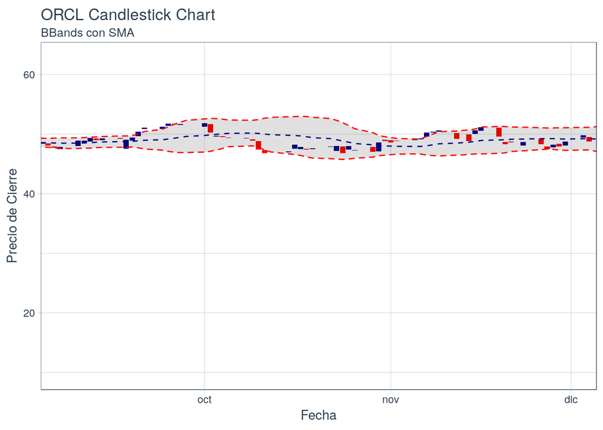

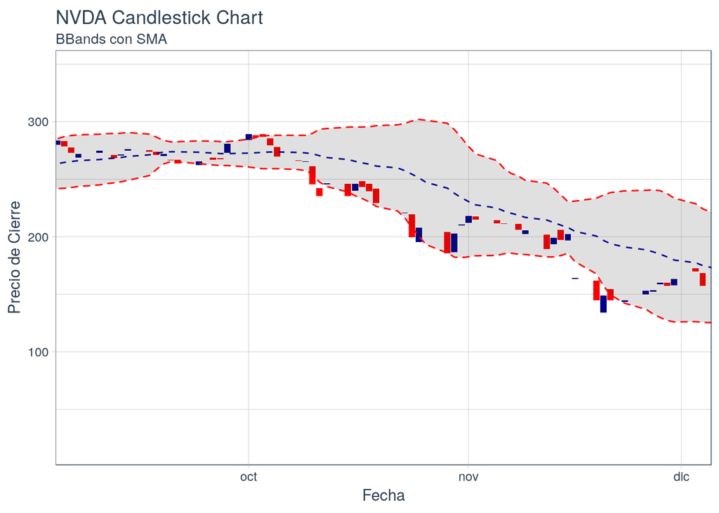

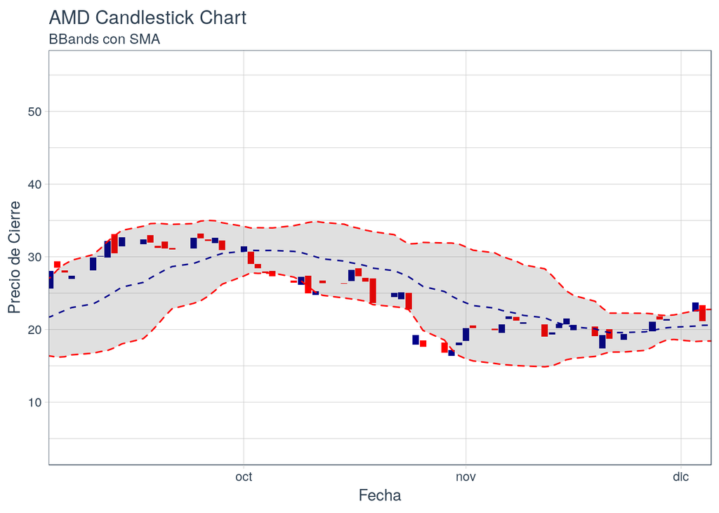

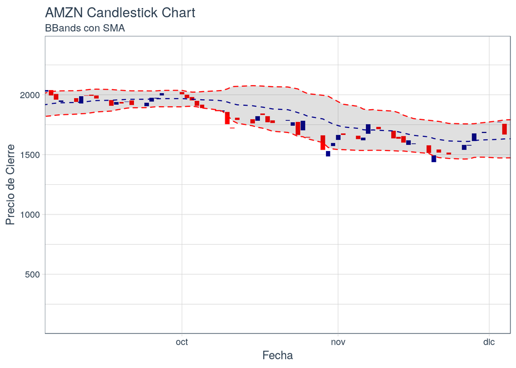

```r
map_stock <- stock_daily_tbl %>%
  group_by(symbol) %>%
  nest() %>%
  mutate(plot = map2(data, symbol, bbands_function))
```

## Pregunta 2.5

Investigue respecto a las empresas tecnológicas antes mencionadas[^2], luego construya un portafolio que se vaya rebalanceando mensualemente. Grafique los retornos del portafolio creado.

```r
w <- c(0.25, 0.25, 0.25, 0.25)
```

```r
portfolio_returns_monthly <- stock_returns_monthly_tbl %>%
  gather(asset, returns, -date) %>%
  tq_portfolio(assets_col =  asset,
    returns_col = returns,
    weights = w,
    col_rename = "returns",
    rebalance_on = "months")
```

[figure not shown]

```r
portfolio_returns_monthly %>%
  mutate(returns = round(returns,4)*100) %>%
  ggplot(aes(x=date, y=returns)) +
  geom_bar(stat="identity", fill = "orange") +
  labs(title = "Retornos Portfolio",
       subtitle = "Data Viz. usando ggplot2",
       x = "Fecha", y = "Retornos (%)") +
  theme_tq()
```

[^1]: Una función útil es `str_extract` del paquete **stringr**.
[^2]: Le dará contexto respecto a que pesos asignar a su portafolio.

**Disclaimer** : La información contenida en esta página está bajo una [Licencia Creative Commons Atribución-NoComercial-SinDerivadas 4.0 Internacional](http://creativecommons.org/licenses/by-nc-nd/4.0/) y fue construida bajo mi rol como ayudante (*Teacher Assistant*) de la Catedra Topicos en economía y negocios utilizando R ( *R for economy and business* ).